# Sleep Questionnaire Data

Kaisa Taipale

July 29, 2019

## What is this?

Here I’m doing my own initial exploration of the data provided by Sunny. My plan is to load the data and combine test and training data to make one big dataset for exploration of missingness, distributions of variables, and data quality. Then I’ll split it up for machine learning purposes.

```r
library(ggplot2)
library(tidyverse)
library(GGally)
library(randomForest)
library(calibrate)
survey_train <- read.csv("~/Documents/DataViz/WiSDM project 2019/survey_train.csv")
survey_test <- read.csv("~/Documents/DataViz/WiSDM project 2019/survey_test.csv")
```

```r
dim(survey_test)
```

```
## [1]  67 179
```

```r
dim(survey_train)
```

```
## [1]  65 176
```

Note that the datasets have different dimensions. Sunny noted in her other R code that for the test set she dropped columns 61, 81, and 151 as “meaningless variables”. What are these?

```r
colnames(survey_test)[61]
```

```
## [1] "scoring_cshq_complete"
```

```r
colnames(survey_test)[81]
```

```
## [1] "osa18_quality_of_life_survey_complete"
```

```r
colnames(survey_test)[151]
```

```
## [1] "pediatric_sleep_questionnaire_psq_complete"
```

I see: they primarily indicate if there are any NAs in the respondent’s answers. We can indeed drop those.

```r
survey_test <- survey_test[,c(-61, -81, -151)]
```

Now that we’ve done that, we can glue the two sets.

```r
survey_all <- rbind(survey_test, survey_train)
```

For laziness, use the summary function first!

```r
summary(survey_all)
```

```
##    record_id        age              sex             height
##  CF001  :  1   Min.   : 2.000   Min.   :0.0000   Min.   : 86.5
##  CF004  :  1   1st Qu.: 3.500   1st Qu.:0.0000   1st Qu.:103.5
##  CF005  :  1   Median : 7.000   Median :0.0000   Median :122.9
##  CF006  :  1   Mean   : 6.963   Mean   :0.4729   Mean   :122.9
##  CF007  :  1   3rd Qu.:10.000   3rd Qu.:1.0000   3rd Qu.:139.2
##  CF010  :  1   Max.   :16.000   Max.   :1.0000   Max.   :180.0
##  (Other):126   NA's   :105      NA's   :3        NA's   :105
##      weight            bmi           bed_time  cshq_samebedtime
##  Min.   : 10.90   Min.   :14.10   20:00  :23   Min.   :1.00
##  1st Qu.: 16.25   1st Qu.:15.70   21:00  :20   1st Qu.:1.00
##  Median : 24.50   Median :17.60   20:30  :17   Median :1.00
##  Mean   : 34.75   Mean   :19.93   21:30  :13   Mean   :1.29
##  3rd Qu.: 34.75   3rd Qu.:19.20          :11   3rd Qu.:1.00
##  Max.   :119.00   Max.   :43.70   19:30  :10   Max.   :3.00
##  NA's   :105      NA's   :105     (Other):38   NA's   :1
##  cshq_20mintosleep cshq_asleepownbed cshq_asleepotherbed  cshq_rocking
##  Min.   :1.000     Min.   :1.000     Min.   :1.000       Min.   :1.000
##  1st Qu.:1.000     1st Qu.:1.000     1st Qu.:2.000       1st Qu.:3.000
##  Median :1.000     Median :1.000     Median :3.000       Median :3.000
##  Mean   :1.585     Mean   :1.302     Mean   :2.519       Mean   :2.758
##  3rd Qu.:2.000     3rd Qu.:1.000     3rd Qu.:3.000       3rd Qu.:3.000
##  Max.   :3.000     Max.   :3.000     Max.   :3.000       Max.   :3.000
##  NA's   :2         NA's   :3         NA's   :3           NA's   :8
##  cshq_specialobject cshq_parentsinroom cshq_redyforbed
##  Min.   :1.000      Min.   :1.00       Min.   :1.000
##  1st Qu.:1.000      1st Qu.:2.00       1st Qu.:1.000
##  Median :3.000      Median :3.00       Median :1.000
##  Mean   :2.173      Mean   :2.55       Mean   :1.617
##  3rd Qu.:3.000      3rd Qu.:3.00       3rd Qu.:2.000
##  Max.   :3.000      Max.   :3.00       Max.   :3.000
##  NA's   :5          NA's   :3          NA's   :4
##  cshq_resistsgoingtobed cshq_strugglesatbedtime cshq_afraiddark
##  Min.   :1.000          Min.   :1.000           Min.   :1.000
##  1st Qu.:2.000          1st Qu.:2.000           1st Qu.:2.000
##  Median :3.000          Median :3.000           Median :3.000
##  Mean   :2.336          Mean   :2.654           Mean   :2.504
##  3rd Qu.:3.000          3rd Qu.:3.000           3rd Qu.:3.000
##  Max.   :3.000          Max.   :3.000           Max.   :3.000
##  NA's   :4              NA's   :5               NA's   :3
```

[output cut: 353 more lines]

```
##  Min.   :0.0000   Min.   :0.0000   Min.   :0.0000   Min.   :0.0000
##  1st Qu.:0.0000   1st Qu.:0.0000   1st Qu.:0.0000   1st Qu.:0.0000
##  Median :0.0000   Median :0.0000   Median :0.0000   Median :0.0000
##  Mean   :0.3712   Mean   :0.4091   Mean   :0.5152   Mean   :0.1515
##  3rd Qu.:1.0000   3rd Qu.:1.0000   3rd Qu.:2.0000   3rd Qu.:0.0000
##  Max.   :2.0000   Max.   :2.0000   Max.   :2.0000   Max.   :2.0000
##
##  posterior_bite_score dental_tool_score
##  Min.   :0.0000       Min.   : 0.000
##  1st Qu.:0.0000       1st Qu.: 0.000
##  Median :0.0000       Median : 2.000
##  Mean   :0.1212       Mean   : 2.424
##  3rd Qu.:0.0000       3rd Qu.: 4.000
##  Max.   :2.0000       Max.   :11.000
##
```

Now missingness: what’s the missingness like by variable?

```r
colSums(is.na(survey_all))
```

```
##                   record_id                         age
##                           0                         105
##                         sex                      height
##                           3                         105
##                      weight                         bmi
##                         105                         105
##                    bed_time            cshq_samebedtime
##                           0                           1
##           cshq_20mintosleep           cshq_asleepownbed
##                           2                           3
##         cshq_asleepotherbed                cshq_rocking
##                           3                           8
##          cshq_specialobject          cshq_parentsinroom
##                           5                           3
##             cshq_redyforbed      cshq_resistsgoingtobed
##                           4                           4
##     cshq_strugglesatbedtime             cshq_afraiddark
##                           5                           3
##  cshq_afraidofsleepingalone               cshq_hrssleep
##                           2                           2
##               cshq_sleepmin           cshq_sleepslittle
##                          65                           7
##             cshq_sleepsmuch         cshq_sleepsrightamt
##                           8                           4
##       cshq_sleepsameeachday                cshq_wetsbed
##                           2                           4
##                  cshq_talks               cshq_restless
##                           5                           6
##              cshq_sleepwalk                cshq_movebed
##                           7                           6
##                   cshq_pain             cshq_pain_where
##                           7                           0
##             cshq_grindteeth                 cshq_snores
##                           4                          11
##          cshq_stopbreathing              cshq_snortgasp
##                           7                           5
##          cshq_sleepawayhome         cshq_complainssleep
##                           5                           6
##              cshq_screaming              cshq_nightmare
##                           6                           5
```

[output cut: 121 more lines]

```
##                           0                          24
##               activity_days               exercise_days
##                          16                          25
##              exercise_hours                orthodontist
##                           8                           6
##       orthodontic_treatment               profile_score
##                           6                           0
##    midface_deficiency_score     lower_face_height_score
##                           0                           0
##            lip_strain_score                palate_score
##                           0                           0
##               overjet_score             overjbite_score
##                           0                           0
##        posterior_bite_score           dental_tool_score
##                           0                           0
```

The demographics are almost all missing – I have 105 missing values for age, height, weight, bmi. The QL child reports are also highly missing, and the QL parent responses somewhat missing…. Craniofacial data are all there (zero missing!).

```r
rowSums(is.na(survey_all))
```

```
##   [1]  27  27  27   4  28  27   4  33  24   7   0   7  11   2   2   5   5
##  [18]  27   2  25   0  37   6   6   4  30   2  25  27  24   4  24 151  84
##  [35]   6   6  55   7  14  49   5   4  23   5   5  27   9  20  97  23  48
##  [52]  42   4  34   5   9  10   8  11  14   6   6   7  12  19  12  11  27
##  [69]  28  28  32  27  17   4   6   1   8   3  26  33  25  27   6  26  24
##  [86]   1  24   2  29   5  23   4   4  25   5  27  28  31  29   8  27   4
## [103]   5  31  62  30  22   9  13   4  47  43  28   4   8  14   9   9   8
## [120]  29   8   7  15  38  39   5   5  34  11   8   7  28
```

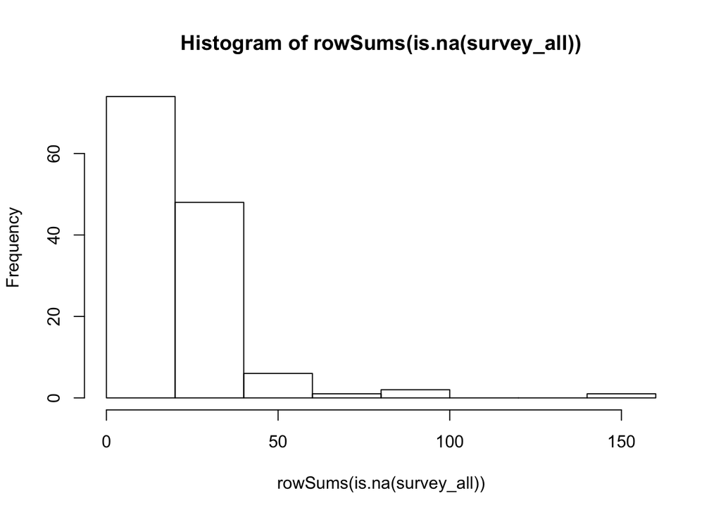

```r
hist(rowSums(is.na(survey_all)))
```

Just looking at this, I’m tempted to put a cutoff of 50 missing – if we do that, 5 respondents would be dropped. This is an arbitrary number.

## Visualizations

### Histograms of numeric responses

Before dropping any missing values, let’s do some visualization of distributions of answers.

First I’ll create a column from the record_id that is binary and identifies each patient as having the problem (CF records) or not having the problem (Control records). Then I’ll drop all the columns that are characters etc, retaining only columns that are numeric. Last, in this part, I’ll graph control against patient for numeric responses.

To create the patient-or-control column, I’m going to be lazy and simply extract the first two characters of the record_id column and make that my factor!

```r
survey_all$patient <- factor(substr(survey_all$record_id, start = 1, stop = 2))
```

Now let’s create a dataframe that consists only of numeric columns. We will also drop height, age, weight, and bmi: there are so many missing values that they’re essentially useless.

Moreover, I’m going to drop gender, person_completing_form, osa_overall, and psq_total_yes. In previous work gender has not proved to be significant, and indeed a visual inspection indicates there’s not a lot of difference. The same is true for sex, another column!

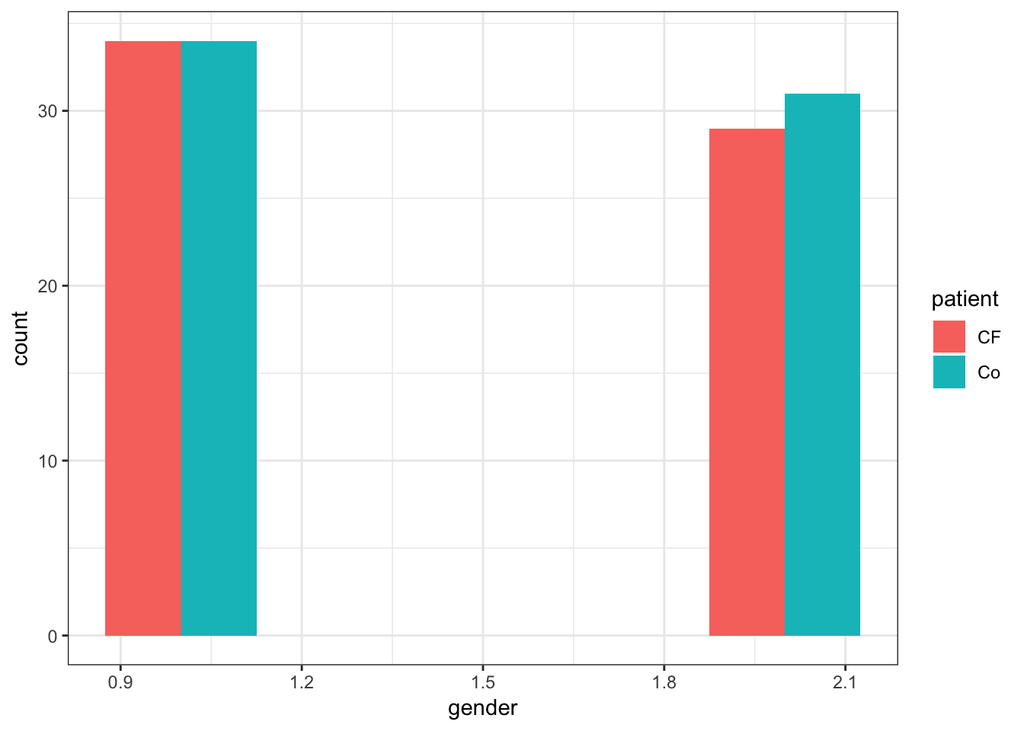

```r
ggplot(survey_all,aes(x=gender,group=patient,fill=patient))+
     geom_histogram(position="dodge",binwidth=0.25)+theme_bw()
```

Person_completing_form is not a clinical presentation, and osa_overall and psq_total_yes are summary variables – I don’t like including summary variables in SVD exploration because they inevitably show up as more important than all their components.

```r
nums <- unlist(lapply(survey_all, is.numeric))
numbers_only <- survey_all[ , nums]
numbers_only <- numbers_only[, -which(names(numbers_only) %in% c("age","weight","height","bmi", "gender","sex", "person_completing_form", "psq_total_yes","osa_overall"))]
```

This numeric-only dataframe will be helpful when we carry out SVD. We’ll glue back on the factors corresponding to patient or control to color accordingly; we can also use that right now in constructing ggplot histograms.

```r
numbers_and_status <- numbers_only
numbers_and_status$patient <- survey_all$patient
```

Time for the histograms! Ok – didn’t finish this :) will come back.

# Some data management

Since I’m only exploring data right now, I’m not going to do the train-test split yet – just impute for everything (!) and then do SVD. ## Imputation of missing values

Here I’m using Sunny’s code and just using random forest for imputation of missing values.

```r
numbers_imputed <- rfImpute(numbers_and_status, y = numbers_and_status$patient,  iter=5, ntree=300)
```

```
## ntree      OOB      1      2
##   300:   4.55%  3.08%  5.97%
## ntree      OOB      1      2
##   300:   4.55%  4.62%  4.48%
## ntree      OOB      1      2
##   300:   3.79%  3.08%  4.48%
## ntree      OOB      1      2
##   300:   7.58%  6.15%  8.96%
## ntree      OOB      1      2
##   300:   3.79%  4.62%  2.99%
```

## Singular value decomposition on imputed data

Now I’ll do some singular value decomposition as I love to look at SVD for understanding! I will scale the answers, as otherwise night waking minutes and sleepmin will take over the answers.

```r
svd_on_responses <- svd(scale(numbers_imputed[, -which(names(numbers_imputed) %in% c("patient","numbers_and_status$patient"))]))
```

Look at the distribution of singular values:

```r
svd_on_responses$d/sum(svd_on_responses$d)
```

```
##   [1] 5.590533e-02 2.535433e-02 2.442905e-02 2.133497e-02 2.026604e-02
##   [6] 2.009054e-02 1.808351e-02 1.759870e-02 1.691809e-02 1.625798e-02
##  [11] 1.614995e-02 1.524781e-02 1.495636e-02 1.481664e-02 1.412135e-02
##  [16] 1.390884e-02 1.367663e-02 1.345999e-02 1.317407e-02 1.305929e-02
##  [21] 1.283664e-02 1.251779e-02 1.245826e-02 1.224585e-02 1.210214e-02
##  [26] 1.200132e-02 1.180668e-02 1.162355e-02 1.141470e-02 1.127346e-02
##  [31] 1.098095e-02 1.075637e-02 1.055170e-02 1.039100e-02 1.013051e-02
##  [36] 9.968635e-03 9.872310e-03 9.723239e-03 9.620289e-03 9.506711e-03
##  [41] 9.229621e-03 9.111413e-03 9.044657e-03 8.846152e-03 8.774359e-03
##  [46] 8.527588e-03 8.363398e-03 8.265511e-03 8.049050e-03 8.007907e-03
##  [51] 7.928677e-03 7.816926e-03 7.729704e-03 7.513996e-03 7.481004e-03
##  [56] 7.403131e-03 7.254273e-03 7.116324e-03 7.090522e-03 6.917771e-03
##  [61] 6.689279e-03 6.500229e-03 6.472610e-03 6.358408e-03 6.197568e-03
##  [66] 6.156016e-03 5.905312e-03 5.842559e-03 5.808054e-03 5.655468e-03
##  [71] 5.537795e-03 5.502546e-03 5.435875e-03 5.342003e-03 5.201653e-03
##  [76] 5.012018e-03 4.992700e-03 4.870543e-03 4.823491e-03 4.793170e-03
##  [81] 4.695002e-03 4.548102e-03 4.444492e-03 4.341972e-03 4.214066e-03
##  [86] 4.156932e-03 4.017831e-03 3.986868e-03 3.916289e-03 3.802003e-03
##  [91] 3.687237e-03 3.551613e-03 3.493239e-03 3.461583e-03 3.348569e-03
##  [96] 3.263607e-03 3.135496e-03 3.089951e-03 2.993759e-03 2.938221e-03
## [101] 2.852832e-03 2.797906e-03 2.716618e-03 2.601695e-03 2.578642e-03
## [106] 2.407792e-03 2.344671e-03 2.276445e-03 2.102368e-03 1.991513e-03
## [111] 1.975450e-03 1.836901e-03 1.795475e-03 1.744992e-03 1.716199e-03
## [116] 1.617558e-03 1.541440e-03 1.437371e-03 1.373926e-03 1.319351e-03
## [121] 1.248419e-03 1.170447e-03 1.122298e-03 1.072504e-03 9.671801e-04
## [126] 9.355019e-04 8.488576e-04 7.987052e-04 6.701251e-04 6.079125e-04
## [131] 2.812093e-04 2.482695e-17
```

Looking at the cumulative sum of singular values, it’s clear that many variables are close in importance.

```r
cumsum(svd_on_responses$d/sum(svd_on_responses$d))
```

```
##   [1] 0.05590533 0.08125966 0.10568872 0.12702368 0.14728973 0.16738026
##   [7] 0.18546378 0.20306247 0.21998057 0.23623855 0.25238850 0.26763631
##  [13] 0.28259267 0.29740931 0.31153066 0.32543950 0.33911613 0.35257612
##  [19] 0.36575018 0.37880947 0.39164612 0.40416391 0.41662217 0.42886801
##  [25] 0.44097015 0.45297147 0.46477816 0.47640171 0.48781641 0.49908987
##  [31] 0.51007082 0.52082719 0.53137889 0.54176989 0.55190040 0.56186903
##  [37] 0.57174134 0.58146458 0.59108487 0.60059158 0.60982120 0.61893262
##  [43] 0.62797727 0.63682343 0.64559778 0.65412537 0.66248877 0.67075428
##  [49] 0.67880333 0.68681124 0.69473992 0.70255684 0.71028654 0.71780054
##  [55] 0.72528155 0.73268468 0.73993895 0.74705527 0.75414580 0.76106357
##  [61] 0.76775284 0.77425307 0.78072568 0.78708409 0.79328166 0.79943767
##  [67] 0.80534299 0.81118555 0.81699360 0.82264907 0.82818686 0.83368941
##  [73] 0.83912528 0.84446729 0.84966894 0.85468096 0.85967366 0.86454420
##  [79] 0.86936769 0.87416086 0.87885586 0.88340397 0.88784846 0.89219043
##  [85] 0.89640450 0.90056143 0.90457926 0.90856613 0.91248242 0.91628442
##  [91] 0.91997166 0.92352327 0.92701651 0.93047809 0.93382666 0.93709027
##  [97] 0.94022576 0.94331572 0.94630948 0.94924770 0.95210053 0.95489843
## [103] 0.95761505 0.96021675 0.96279539 0.96520318 0.96754785 0.96982430
## [109] 0.97192666 0.97391818 0.97589363 0.97773053 0.97952600 0.98127100
## [115] 0.98298719 0.98460475 0.98614619 0.98758356 0.98895749 0.99027684
## [121] 0.99152526 0.99269571 0.99381800 0.99489051 0.99585769 0.99679319
## [127] 0.99764205 0.99844075 0.99911088 0.99971879 1.00000000 1.00000000
```

Look at plot of patients:

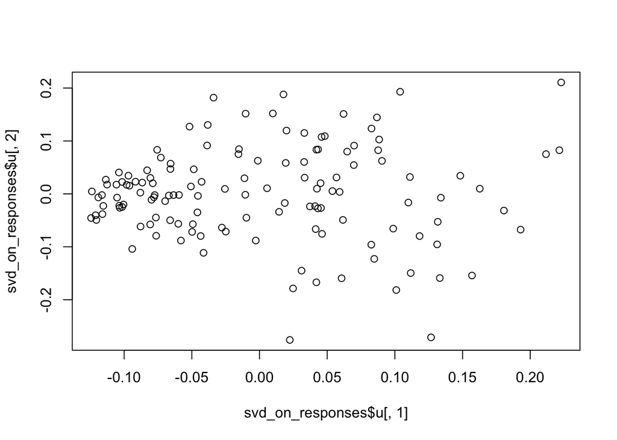

```r
plot(svd_on_responses$u[,1],svd_on_responses$u[,2])
```

Look at plot of survey responses:

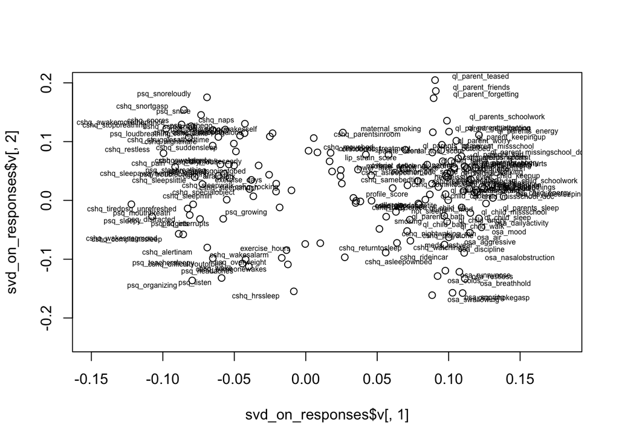

```r
plot(svd_on_responses$v[,1],svd_on_responses$v[,2], xlim = c(-.15,.18), ylim = c(-.24,.2))
textxy(svd_on_responses$v[,1],svd_on_responses$v[,2], colnames(numbers_imputed[, -which(names(numbers_imputed) %in% c("patient","numbers_and_status$patient"))]))
```

Time to make this prettier and color by factor. Need some dataframes to use ggplot.

```r
svd_people_df <- data.frame(svd_on_responses$u)
svd_people_df$patient <- numbers_and_status$patient
```

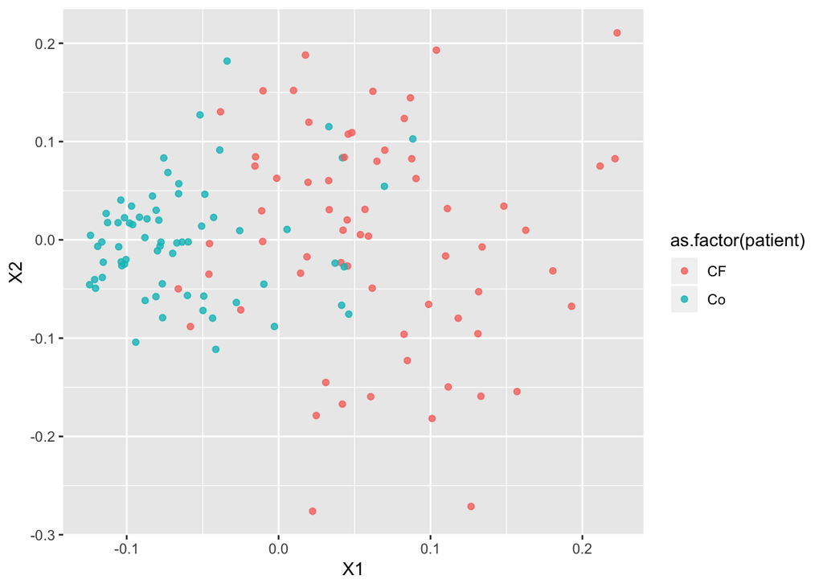

```r
p <- ggplot(data.frame(svd_people_df), aes(x=X1, y=X2, color = as.factor(patient)))
p+geom_point(alpha=0.8)+scale_fill_brewer(palette="Set1")
```

Cool. There’s definitely some differentiation simply based on questionnaire responses. Does this also hold in the next few dimensions?

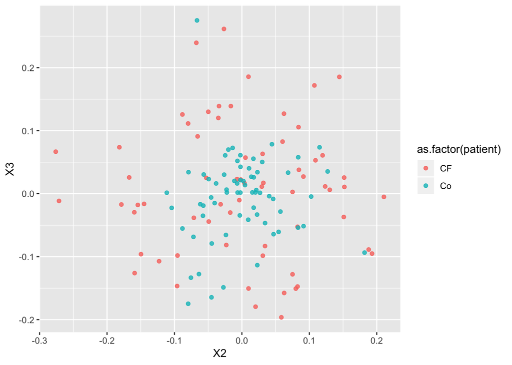

```r
p <- ggplot(data.frame(svd_people_df), aes(x=X2, y=X3, color = as.factor(patient)))
p+geom_point(alpha=0.8)+scale_fill_brewer(palette="Set1")
```

Very weird graphing second and third singular components against each other!!!! Like a bullseye instead of a linear separation. What are the variables that go with this?

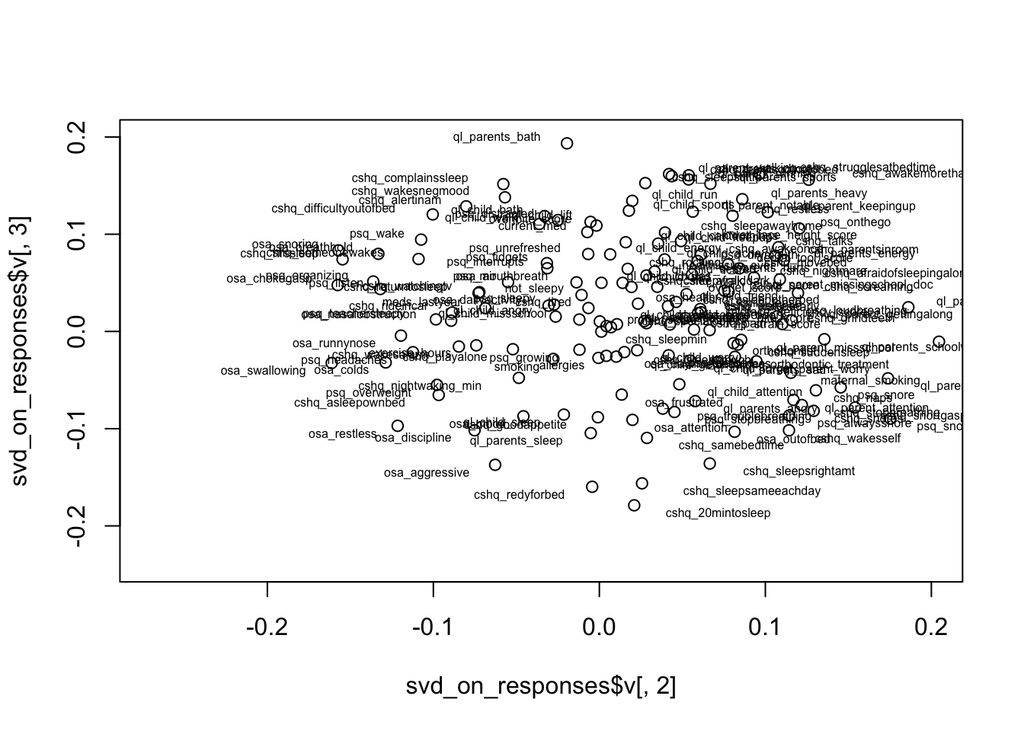

```r
plot(svd_on_responses$v[,2],svd_on_responses$v[,3], xlim = c(-.27,.2), ylim = c(-.24,.2))
textxy(svd_on_responses$v[,2],svd_on_responses$v[,3], colnames(numbers_imputed[, -which(names(numbers_imputed) %in% c("patient","numbers_and_status$patient"))]))
```

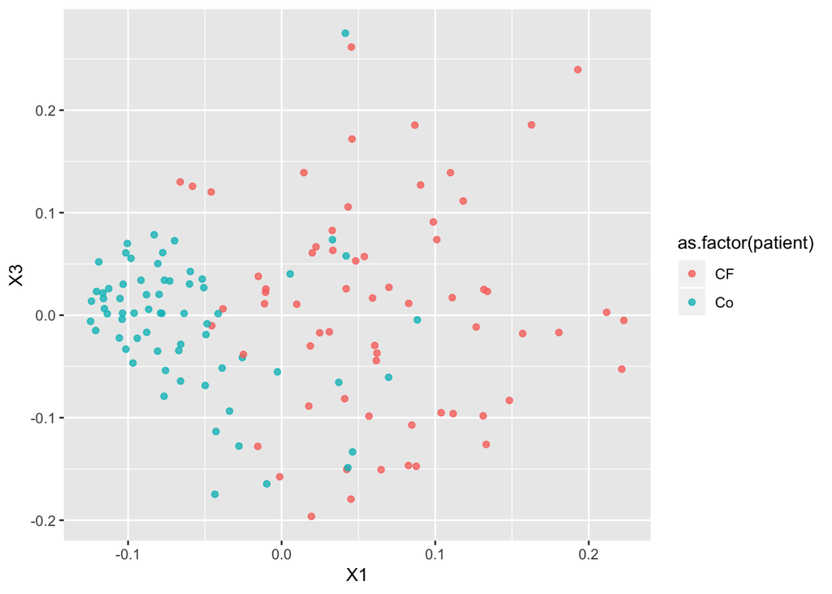

```r
p <- ggplot(data.frame(svd_people_df), aes(x=X1, y=X3, color = as.factor(patient)))
p+geom_point(alpha=0.8)+scale_fill_brewer(palette="Set1")
```

X1 against X3 certainly has a more linear separation boundary.

Ok. What I conclude from this exercise is that there’s a strong linear effect initially, but then there is some lower-lying nonlinear behavior that needs to be addressed somehow.

I’d like to talk with a domain expert about what we see with the factors from the questionnaire. I see patterns, but don’t know enough about the topic to know how to exploit them. From my limited understanding based in part on covertly reading my husband’s medical journals, there are often distinct problems with similar presentations, and so further methods should be pursued to see if there might be mixtures presenting with the same clinical diagnosis.

One such avenue would be using clustering on symptoms/survey responses, as well as on patients, and then following up with (for instance) some topological data analysis to contrast with the clustering results.